# Small Claims: Comanche County 00-19

Leticia Calvillo, Fellow

Open Justice Oklahoma

2021-05-17

Background information: Why are we researching this topic? What is the expected product? A blog post? Analysis for an internal or external partner?

This project aims to shed light on the extent of medical debt in Oklahoma. The goal is to produce blog posts, fact sheets, and/or reports that emphasize the scale of the medicial debt problem in Oklahmoa and urge citizens to vote in favor of SQ 802.

# 1 Data sources

Where is the data from? The ojo database? OSCN? ODCR? Crime in Oklahoma reports?

The data is from the ojo database.

## 1.1 Timeframe

What years/months are you looking at? Year of case filing, first disposition, prison admission, etc.? Be as specific as possible.

The analysis aims to identify trends in medical debt cases over the past 20 years (2000-2019).

## 1.2 Geography

What courts/counties/states are you looking at?

This analysis focuses on small claims court cases in Comanche County.

## 1.3 Variables

What variables did you use? What types of cases, crimes, etc.?

This project focuses on medical debt cases.

## 1.4 Query

If you’re using data from the OJO database, include the query you used to pull your data. This may be a function that starts `ojo_query_` or `dbGetQuery`.

```r
sc <- ojo_query_disps("COMANCHE", "SC", 2000:2019)
```

This gives us over 89,510 rows of data. Each row in the table is a disposition; since there may be multiple dispositions per case, we should expect that the number of cases is somewhat lower.

# 2 Checking Data

Explain the results of the checks of your data.

## 2.1 Check for Completeness

If you’re using court data, you can use the `ojo_check_comp` to see how complete the data is.

```r
#ojo_check_comp(sc)

#completeness
```

## 2.2 Check for NAs

Detail the NAs and blank items in your data and, if necessary and possible, fill them in.

A large portion of the “iss_plaint” data for the early 2000s is missing.

```r
nas_plaint<- sc %>%
  group_by(casenum) %>%
  filter(all(is.na(iss_plaint) | iss_plaint == ""))

nas_plaint
```

```
## # A tibble: 12,372 x 12
## # Groups:   casenum [12,182]
##    court  casenum   casetype file_year file_date  defname iss_no iss_desc
##    <chr>  <chr>     <chr>        <int> <date>     <chr>   <chr>  <chr>
##  1 COMAN… SC-2000-… SC            2000 NA         <NA>    1      INDEBTEDNESS
##  2 COMAN… SC-2000-… SC            2000 NA         <NA>    1      INDEBTEDNESS
##  3 COMAN… SC-2000-… SC            2000 NA         <NA>    1      INDEBTEDNESS
##  4 COMAN… SC-2000-… SC            2000 NA         <NA>    1      FORCIBLE ENTRY…
##  5 COMAN… SC-2000-… SC            2000 NA         <NA>    1      FORCIBLE ENTRY…
##  6 COMAN… SC-2000-… SC            2000 NA         <NA>    1      INDEBTEDNESS
##  7 COMAN… SC-2000-… SC            2000 NA         <NA>    1      INDEBTEDNESS
##  8 COMAN… SC-2000-… SC            2000 NA         <NA>    1      INDEBTEDNESS
##  9 COMAN… SC-2000-… SC            2000 NA         <NA>    1      INDEBTEDNESS
## 10 COMAN… SC-2000-… SC            2000 NA         <NA>    1      INDEBTEDNESS >…
## # … with 12,362 more rows, and 4 more variables: iss_plaint <chr>,
## #   disp_date <date>, disp <chr>, disp_type <chr>
```

```r
nas_plaint <- nas_plaint %>%
  group_by(casenum) %>%
  slice(1)

year_nas_plaint <- nas_plaint%>%
  ungroup %>%
  count(file_year)

year_nas_plaint
```

```
## # A tibble: 18 x 2
##    file_year     n
##        <int> <int>
##  1      2000  4435
##  2      2001  4683
##  3      2002  2972
##  4      2003    10
##  5      2004    23
##  6      2005     5
##  7      2006     3
##  8      2009     1
##  9      2010     2
## 10      2011    10
## 11      2012    14
## 12      2013     5
## 13      2014     3
## 14      2015     5
## 15      2016     1
## 16      2017     6
## 17      2018     3
## 18      2019     1
```

Most of the missing plaintiff data occurs in years 2000-2002.

```r
nas_desc <- sc %>%
  group_by(casenum) %>%
  filter(all(is.na(iss_desc) | iss_desc == ""))

nas_desc
```

```
## # A tibble: 6 x 12
## # Groups:   casenum [6]
##   court casenum casetype file_year file_date  defname iss_no iss_desc iss_plaint
##   <chr> <chr>   <chr>        <int> <date>     <chr>   <chr>  <chr>    <chr>
## 1 COMA… SC-200… SC            2000 NA         <NA>    1      ""       ""
## 2 COMA… SC-200… SC            2000 NA         <NA>    1      ""       ""
## 3 COMA… SC-200… SC            2000 NA         <NA>    1      ""       ""
## 4 COMA… SC-200… SC            2001 NA         <NA>    1      ""       ""
## 5 COMA… SC-200… SC            2003 NA         PURHAM… 1      ""       ""
## 6 COMA… SC-200… SC            2006 NA         RIZZO-… 2      ""       ""
## # … with 3 more variables: disp_date <date>, disp <chr>, disp_type <chr>
```

```r
nas_desc <- nas_desc%>%
  group_by(casenum) %>%
  slice(1)

year_nas_desc <- nas_desc%>%
  ungroup %>%
  count(file_year)

year_nas_desc
```

```
## # A tibble: 4 x 2
##   file_year     n
##       <int> <int>
## 1      2000     3
## 2      2001     1
## 3      2003     1
## 4      2006     1
```

```r
connect_ojo()
```

Query oscn_party_names table for missing plaintiffs.

```r
party_names <- dbGetQuery(ojo_db, glue_sql("SELECT * FROM oscn_party_names
                          WHERE court = 'COMANCHE'
                          AND casenum IN ({nas_plaint$casenum*})",
                                           .con = ojo_db))
```

Filter for the first plaintiff name in each case

```r
plaint_names <- party_names %>%
  filter(party_type == "Plaintiff") %>%
  group_by(casenum) %>%
  slice(1) %>%
  select(casenum, iss_plaintiff = party)
```

Add new plaintiff names to nas_plaint dataframe

```r
nas_plaint <- nas_plaint %>%
  select(-iss_plaint) %>%
  left_join(plaint_names)
```

```r
sc2 <- sc%>%
  filter(!casenum %in% nas_plaint$casenum) %>%
  bind_rows(nas_plaint)
```

```r
nas_plaint <- sc2 %>%
  group_by(casenum) %>%
  filter(all(is.na(iss_plaint) | iss_plaint == ""))
```

```r
sc<- sc2
```

```r
nas_plaint<- sc %>%
  group_by(casenum) %>%
  filter(all(is.na(iss_plaint) | iss_plaint == ""))

nas_plaint
```

```
## # A tibble: 12,182 x 13
## # Groups:   casenum [12,182]
##    court  casenum   casetype file_year file_date  defname iss_no iss_desc
##    <chr>  <chr>     <chr>        <int> <date>     <chr>   <chr>  <chr>
##  1 COMAN… SC-2000-… SC            2000 NA         <NA>    1      INDEBTEDNESS
##  2 COMAN… SC-2000-… SC            2000 NA         <NA>    1      INDEBTEDNESS
##  3 COMAN… SC-2000-… SC            2000 NA         <NA>    1      INDEBTEDNESS
##  4 COMAN… SC-2000-… SC            2000 NA         <NA>    1      FORCIBLE ENTRY…
##  5 COMAN… SC-2000-… SC            2000 NA         <NA>    1      FORCIBLE ENTRY…
##  6 COMAN… SC-2000-… SC            2000 NA         <NA>    1      INDEBTEDNESS
##  7 COMAN… SC-2000-… SC            2000 NA         <NA>    1      INDEBTEDNESS
##  8 COMAN… SC-2000-… SC            2000 NA         <NA>    1      INDEBTEDNESS
##  9 COMAN… SC-2000-… SC            2000 NA         <NA>    1      INDEBTEDNESS
## 10 COMAN… SC-2000-… SC            2000 NA         <NA>    1      INDEBTEDNESS >…
## # … with 12,172 more rows, and 5 more variables: iss_plaint <chr>,
## #   disp_date <date>, disp <chr>, disp_type <chr>, iss_plaintiff <chr>
```

```r
nas_plaint <- nas_plaint %>%
  group_by(casenum) %>%
  slice(1)

year_nas_plaint <- nas_plaint%>%
  ungroup %>%
  count(file_year)

year_nas_plaint
```

```
## # A tibble: 18 x 2
##    file_year     n
##        <int> <int>
##  1      2000  4435
##  2      2001  4683
##  3      2002  2972
##  4      2003    10
##  5      2004    23
##  6      2005     5
##  7      2006     3
##  8      2009     1
##  9      2010     2
## 10      2011    10
## 11      2012    14
## 12      2013     5
## 13      2014     3
## 14      2015     5
## 15      2016     1
## 16      2017     6
## 17      2018     3
## 18      2019     1
```

```r
mins <- ojo_query_mins("COMANCHE", "SC", 2000:2019, min_code = "A/")
```

```
## [1] "SC 2000 minutes queried for OSCN courts: COMANCHE"
## [1] "SC 2001 minutes queried for OSCN courts: COMANCHE"
## [1] "SC 2002 minutes queried for OSCN courts: COMANCHE"
## [1] "SC 2003 minutes queried for OSCN courts: COMANCHE"
## [1] "SC 2004 minutes queried for OSCN courts: COMANCHE"
## [1] "SC 2005 minutes queried for OSCN courts: COMANCHE"
## [1] "SC 2006 minutes queried for OSCN courts: COMANCHE"
## [1] "SC 2007 minutes queried for OSCN courts: COMANCHE"
## [1] "SC 2008 minutes queried for OSCN courts: COMANCHE"
## [1] "SC 2009 minutes queried for OSCN courts: COMANCHE"
## [1] "SC 2010 minutes queried for OSCN courts: COMANCHE"
## [1] "SC 2011 minutes queried for OSCN courts: COMANCHE"
## [1] "SC 2012 minutes queried for OSCN courts: COMANCHE"
## [1] "SC 2013 minutes queried for OSCN courts: COMANCHE"
## [1] "SC 2014 minutes queried for OSCN courts: COMANCHE"
## [1] "SC 2015 minutes queried for OSCN courts: COMANCHE"
## [1] "SC 2016 minutes queried for OSCN courts: COMANCHE"
## [1] "SC 2017 minutes queried for OSCN courts: COMANCHE"
## [1] "SC 2018 minutes queried for OSCN courts: COMANCHE"
## [1] "SC 2019 minutes queried for OSCN courts: COMANCHE"
```

```r
mins <- mins %>%
  mutate(debt_amt = min_desc %>%
           str_remove_all("[:alpha:]|\\$|,") %>%
           str_squish %>%
           as.numeric)


debt_amts <- mins %>%
  select(casenum, debt_amt)
```

```r
new <- left_join(sc, debt_amts, by= "casenum")

sc <- new
```

Summarize case number

```r
#sc <- sc %>%
  #group_by(casenum) %>%
  #slice(1)
```

```r
sc %>%
  count(iss_desc) %>%
  arrange(desc(n))
```

```
##                                iss_desc     n
## 1             FORCIBLE ENTRY & DETAINER 38152
## 2                          INDEBTEDNESS 37950
## 3                  INDEBTEDNESS >$1500.  8321
## 4     FORCIBLE ENTRY & DETAINER >$1500.  2292
## 5                AFFIDAVIT FOR REPLEVIN  1237
## 6        AFFIDAVIT FOR REPLEVIN >$1500.   834
## 7               INDEBTEDNESS >$5000.00.   131
## 8                          INTERPLEADER    95
## 9           REPLEVIN - CIVIL NO DAMAGES    83
## 10                             REPLEVIN    68
## 11               INTERPLEADER >$1500.00    41
## 12 FORCIBLE ENTRY & DETAINER >$5000.00.    39
## 13          BREACH AGREEMENT - CONTRACT    16
## 14                    ASSAULT & BATTERY    14
```

[output cut: 29 more lines]

We see that over 38,148 cases are evictions. We can discard those.

We use the str_detect() function to look for rows with the character string “FORC” in order to catch both “FORCIBLE ENTRY & DETAINER” and “FORCIBLE ENTRY & DETAINER >$1500”, plus any others that may be similar. Putting a ! before it means we want the rows where the string is not detected.

```r
debt <- sc %>%
  filter(!str_detect(iss_desc, "FORC|REPLEVIN|BREACH"))

debt %>%
  count(iss_desc) %>%
  arrange(desc(n))
```

```
##                           iss_desc     n
## 1                     INDEBTEDNESS 37950
## 2             INDEBTEDNESS >$1500.  8321
## 3          INDEBTEDNESS >$5000.00.   131
## 4                     INTERPLEADER    95
## 5           INTERPLEADER >$1500.00    41
## 6                ASSAULT & BATTERY    14
## 7                      FORECLOSURE    14
## 8                                      9
## 9         FORFEITURE OF AUTOMOBILE     5
## 10              ABANDONED PROPERTY     2
## 11  INJUNCTION / RESTRAINING ORDER     2
## 12          INTERPLEADER >$5000.00     2
## 13                 AUTO NEGLIGENCE     1
## 14           AUTOMOBILE NEGLIGENCE     1
## 15   AUTOMOBILE NEGLIGENCE >$1500.     1
## 16           CANCELLATION OF LEASE     1
## 17                         DAMAGES     1
## 18     DIVORCE WITH MINOR CHILDREN     1
## 19        FORFEITURE OF CONTRABAND     1
## 20             INDEBTEDNESS > 1500     1
## 21               INDEBTEDNESS 1500     1
## 22         INDEBTEDNESS UNDER 1500     1
## 23             INDEBTENESS > $1500     1
## 24                      INDEBTNESS     1
## 25 JUVENILE IN NEED OF SUPERVISION     1
## 26                      NEGLIGENCE     1
## 27                 PROMISSORY NOTE     1
## 28                 TEDNESS >$1500.     1
```

Medical debt cases will be filed with “Indebtedness” issues only. We discard all other cases.

```r
debt <- debt %>%
  filter(str_detect(iss_desc, "DEBT"))

debt %>%
  count(iss_desc) %>%
  arrange(desc(n))
```

```
##                  iss_desc     n
## 1            INDEBTEDNESS 37950
## 2    INDEBTEDNESS >$1500.  8321
## 3 INDEBTEDNESS >$5000.00.   131
## 4     INDEBTEDNESS > 1500     1
## 5       INDEBTEDNESS 1500     1
## 6 INDEBTEDNESS UNDER 1500     1
## 7     INDEBTENESS > $1500     1
## 8              INDEBTNESS     1
```

## 2.3 Medical Providers

Next, we will use the mutate() function to classify the cases that have a medical provider plaintiff.

Let’s start by finding the most common plaintiffs:

```r
debt %>%
  count(iss_plaint) %>%
  arrange(desc(n))
```

```
##                                              iss_plaint    n
## 1                                                  <NA> 7419
## 2                     COMANCHE COUNTY MEMORIAL HOSPITAL 2812
## 3                                       HEARTLAND LOANS 1732
## 4                                         SERVICE LOANS 1584
## 5                                        REPUBLIC LOANS 1316
## 6                                    ROYAL FINANCE CORP 1300
## 7                                    CITY NATIONAL BANK 1083
## 8                                        SOONER FINANCE 1007
## 9                                      SUN LOAN COMPANY  848
## 10                                         BELL FINANCE  796
## 11    COMANCHE COUNTY MEMORIAL HOSPITAL, A PUBLIC TRUST  758
## 12                                      ARDMORE FINANCE  735
## 13                                        ROYAL FINANCE  731
## 14   THE COMANCHE COUNTY HOSPITAL AUTHORITY A PUBLIC TR  721
```

[output cut: 4654 more lines]

Many of the most common plaintiffs are clearly medical providers or financial institutions. We use the case_when() function to classify all rows where one of the words is detected as being filed by a medical provider.

We can also classify the names that contain “BANK” or “LOANS” as not being medical providers. The TRUE category at the end will be applied to all rows that don’t fit any previous conditions.

```r
debt <- debt %>%
  mutate(plaint_type = case_when(str_detect(iss_plaint, "HEALTH|CLINIC|MEDICAL") ~ "MEDICAL",
                                 str_detect(iss_plaint, "BANK|LOANS") ~ "OTHER",
                                 TRUE ~ "UNKNOWN"))
```

To check how many we were able to classify, we’ll look at the count in the plaint_type column.

```r
debt %>%
  count(plaint_type) %>%
  arrange(desc(n))
```

```
##   plaint_type     n
## 1     UNKNOWN 37998
## 2       OTHER  7935
## 3     MEDICAL   474
```

To get the most common plaintiffs that are not classified yet:

```r
debt %>%
  filter(plaint_type == "UNKNOWN") %>%
  count(iss_plaint) %>%
  arrange(desc(n))
```

```
##                                              iss_plaint    n
## 1                                                  <NA> 7419
## 2                     COMANCHE COUNTY MEMORIAL HOSPITAL 2812
## 3                                    ROYAL FINANCE CORP 1300
## 4                                        SOONER FINANCE 1007
## 5                                      SUN LOAN COMPANY  848
## 6                                          BELL FINANCE  796
## 7     COMANCHE COUNTY MEMORIAL HOSPITAL, A PUBLIC TRUST  758
## 8                                       ARDMORE FINANCE  735
## 9                                         ROYAL FINANCE  731
## 10   THE COMANCHE COUNTY HOSPITAL AUTHORITY A PUBLIC TR  721
## 11                                       ADVANCE CREDIT  672
## 12                                   MONEY TREE FINANCE  576
## 13                             WESTERN SHAMROCK FINANCE  534
## 14                                APPROVED CASH ADVANCE  458
```

[output cut: 4539 more lines]

I came up with the following classification:

```r
debt <- debt %>%
  mutate(plaint_type = case_when(str_detect(iss_plaint, "HEALTH|CLINIC|MEDICAL|HOSPITAL|IMAGING\\sCENTER|RADIOLOGY|PEDIATRICS|SURGERY|ALLERGY\\sEAR\\sNOSE\\s&\\sTHROAT|HOPSITAL|DOCTORS\\sMRI|HOSPTIAL|NOSE\\s&\\sTHROAT|EAR\\sNOSE|THROAT\\sINSTITUTE") ~ "MEDICAL",
                                 str_detect(iss_plaint, "BANK|FCU|CREDIT|LOAN|FINANC|CASH|MONEY|WORLD\\sACCEPTANCE|FURNITURE|FUNDING|REALTY|CABLEVISION|ELECTRIC|PAYDAY|PAY\\sDAY|ADVANCE\\sAMERICA|BANCFIRST|BOND|RENTALS|MACARTHUR\\sPARK\\sHOMES|FSNB|CHECKMATE|CARMART|CAR\\sMART|SYCAMORE\\sTRAIL|WESTERN\\sSHAMROCK|AUTO|LEASING|PLUMBING|MECHANICA|APARTMENTS|CHECKSMART|DREAM\\sHOMES|FIDELITY|HOUSING\\sAUTHORITY|PIPPIN\\sBROTHERS|CAR|KLEIN\\sGROUP|HOME\\sFINDERS|REAL\\sESTATE|WATER\\sCONDITIONING") ~ "OTHER",
                                 TRUE ~ "UNKNOWN"))
```

This gives us a count of:

```r
debt %>%
  count(plaint_type) %>%
  arrange(desc(n))
```

```
##   plaint_type     n
## 1       OTHER 27472
## 2     UNKNOWN 13185
## 3     MEDICAL  5750
```

```r
debt %>%
  filter(plaint_type == "UNKNOWN") %>%
  count(iss_plaint) %>%
  arrange(desc(n))
```

```
##                                              iss_plaint    n
## 1                                                  <NA> 7419
## 2                                         WALKER, JAY S   88
## 3                                        WALKER, JAY S.   65
## 4                                       DEVINE ENTITIES   39
## 5                                          WATSON, JACK   26
## 6                                         BLOOM, DELMAN   19
## 7                                     BRANSTETTER, ALAN   18
## 8    VALUED SERVICES OF OKLAHOMA DBA FIRST AMERICAN CAS   17
## 9                                           WALKER, JAY   17
## 10                                         HYNEMAN, KIM   16
## 11                                 MOELLER & ASSOCIATES   16
## 12                                        BANNON, KLARA   15
## 13                             C & C DISTRIBUTORS, INC.   15
## 14                               COMANCHE LUMBER CO INC   14
```

[output cut: 3760 more lines]

This gives us the most common medical plaintiffs:

```r
debt %>%
  filter(plaint_type == "MEDICAL") %>%
  count(iss_plaint) %>%
  arrange(desc(n))
```

```
##                                            iss_plaint    n
## 1                   COMANCHE COUNTY MEMORIAL HOSPITAL 2812
## 2   COMANCHE COUNTY MEMORIAL HOSPITAL, A PUBLIC TRUST  758
## 3  THE COMANCHE COUNTY HOSPITAL AUTHORITY A PUBLIC TR  721
## 4              THE COMANCHE COUNTY HOSPITAL AUTHORITY  347
## 5   COMANCHE COUNTY MEMORIAL HOSPITAL FOUNDATION, INC  140
## 6                     COMANCHE COUNTY HEALTHCARE CORP  125
## 7                                  THE IMAGING CENTER  119
## 8                    COMANCHE COUNTY HEALTHCARE CORP.  106
## 9                         SOUTHWESTERN MEDICAL CENTER   77
## 10  COMANCHE COUNTY MEMORIAL HOSPITAL TRUST AUTHORITY   62
## 11                                   SOONER RADIOLOGY   55
## 12                 COMANCHE COUNTY HOSPITAL AUTHORITY   49
## 13             COMANCHE COUNTY HEALTHCARE CORPORATION   44
## 14                         COMANCHE MEMORIAL HOSPITAL   34
```

[output cut: 85 more lines]

To get a data frame with only the medical debt cases, filter on the plaint_type variable we created.

```r
debt <- debt %>%
  filter(plaint_type == "MEDICAL")
```

# 3 Summarizing and Visualizing Data

## 3.1 Summarizing to the case level

```r
debt <- debt %>%
  group_by(casenum) %>%
  slice(1)
```

That gives us 5,312 lawsuits filed.

## 3.2 Summarizing by year

To find out how many medicial debt cases were filed in Comanche County small claims court each year we just need to count up the number of rows with each distinct file year in our data.

```r
year_sum <- debt %>%
  ungroup %>%
  count(file_year)
```

Now we have a data frame with the number of cases filed in each year. To create a simple line plot with this data:

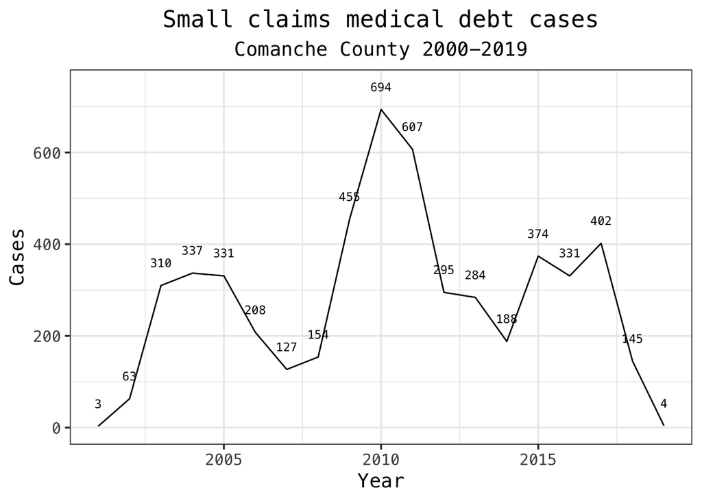

```r
ggplot(year_sum, aes(file_year, n)) +
  geom_line() +
  geom_text(aes(y = n + 50, label = n), family = "Menlo", size = 3) +
  xlab("Year") + ylab("Cases") +
  ylim(0, NA) +
  theme_ojo() +
  theme(plot.title = element_text(hjust = 0.5)) +
  theme(plot.subtitle = element_text(hjust = 0.5)) +
  labs(title = "Small claims medical debt cases",
       subtitle = "Comanche County 2000-2019")
```

```r
debt <- debt %>%
  mutate(plaint_cat = case_when(str_detect(iss_plaint, "COMANCHE COUNTY MEMORIAL") ~ "COMANCHE MEMORIAL HOSPITAL",
                                str_detect(iss_plaint, "THE COMANCHE COUNTY HOSPITAL AUTHORITY") ~ "COMANCHE HOSPITAL AUTHORITY",
                                str_detect(iss_plaint, "COMANCHE COUNTY HEALTHCARE") ~ "COMANCHE HEALTHCARE",
                                TRUE ~ "OTHER"))
```

Now we can see how many cases each group filed each year:

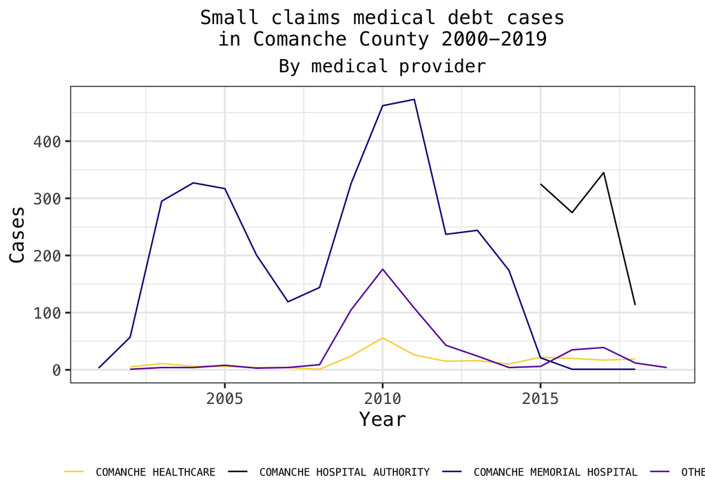

```r
plaint_sum <- debt %>%
  ungroup %>% # Our data frame is still grouped by casenum from the code above; ungroup to summarize using broader groups
  count(file_year, plaint_cat)


ggplot(plaint_sum, aes(file_year, n, group = plaint_cat, color = plaint_cat)) +
  geom_line() +
  xlab("Year") + ylab("Cases")+
  ylim(0, NA) + # Extends y-axis down to zero
  theme_ojo() + # Adds ojo styling to the plot
  theme(legend.title=element_blank())+
  theme(plot.title = element_text(hjust = 0.5, size = 14)) +
  theme(plot.subtitle = element_text(hjust = 0.5, size = 13)) +
  #geom_text(aes(y = n + 50, label = n), family = "Menlo", size = 3) +
  theme(legend.text=element_text(size = 7.5))+
  theme(legend.position="bottom") +
  labs(title = "Small claims medical debt cases\nin Comanche County 2000-2019",
       subtitle = "By medical provider") +
  scale_color_manual(values = ojo_pal) # Gives lines colors from ojo's palette
```

### 3.2.1 Find median debt amount

Created a new dataframe with the median medical debt amount by file_year.

```r
debt_new <- debt%>%
  group_by(file_year) %>%
  summarise(n_cases = n(),
            n_cases_with_debt = sum(!is.na(debt_amt)),
            avg = median(debt_amt, na.rm = TRUE)) %>%
  mutate(pct_with_debt = n_cases_with_debt/n_cases)

debt_new
```

```
## # A tibble: 19 x 5
##    file_year n_cases n_cases_with_debt   avg pct_with_debt
##        <int>   <int>             <int> <dbl>         <dbl>
##  1      2001       3                 0    NA             0
##  2      2002      63                 0    NA             0
##  3      2003     310                 0    NA             0
##  4      2004     337                 0    NA             0
##  5      2005     331                 0    NA             0
##  6      2006     208                 0    NA             0
##  7      2007     127                 0    NA             0
##  8      2008     154                 0    NA             0
##  9      2009     455                 0    NA             0
## 10      2010     694                 0    NA             0
## 11      2011     607                 0    NA             0
## 12      2012     295                 0    NA             0
## 13      2013     284                 0    NA             0
## 14      2014     188                 0    NA             0
## 15      2015     374                 0    NA             0
## 16      2016     331                 0    NA             0
## 17      2017     402                 0    NA             0
## 18      2018     145                 0    NA             0
## 19      2019       4                 0    NA             0
```

### 3.2.2 Graph median medical debt by year

[figure not shown]

```r
ggplot(debt_new, aes(x= file_year, y= avg)) +
  geom_line() +
  #geom_text(aes(y = avg + 50, label = avg), family = "Menlo", size = 3) +
  xlab("Year") + ylab("Amount") +
  ylim(0, NA) + # Extends y-axis down to zero
  theme_ojo() +
  theme(plot.title = element_text(hjust = 0.5)) +
  theme(plot.subtitle = element_text(hjust = 0.5)) +
  labs(title = "Median medical debt amount",
       subtitle = "Comanche County 2000-2019")
```